# CMS AnaStruct Introduction

## Welcome to AnaStruct! Code and documentation here:

https://anastruct.readthedocs.io/en/latest/

AnaStruct is an open source python library that allows for beam element simulations. Setting up a simulation involves the following:

1. Adding system beam elements.
2. Defining fixed point constraints.
3. Defining applied forces.
4. Running the simulation to solve for displacement, reaction forces and bending moments.

While there already exists software that performs a much more refined and sophisticated structural analysis such as Autodesk Inventor or ANSYS, learning to use this library poses a few key benefits...

1. Performing basic structural analysis...duh
2. Learning to problem solve in using someone else's code by reading their documentation.
3. Applying optimization techniques scriptable in python (such as machine learning using Scikit-learn, PyTorch, Tensorflow-keras etc...)

Here is an example of this library used to study the bending performance of a beam withstanding a nonlinear water accumulation load:

https://www.ritchievink.com/blog/2017/08/23/a-nonlinear-water-accumulation-analysis-in-python/

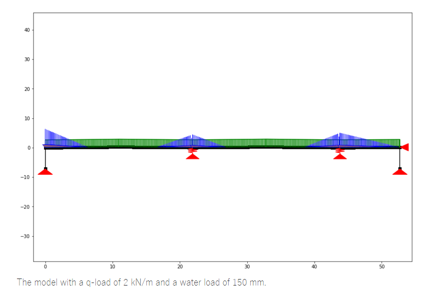

### Shown here is the resulting bending moment diagram from this distribution of water load.

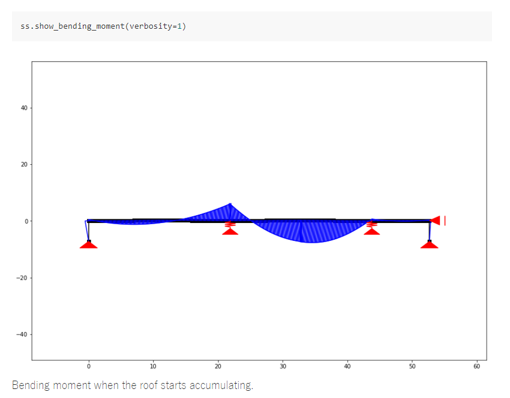

### Anyways...let's get into using the library to work through the 4 steps of using this library...

#### Recall...

1. Adding system beam elements.
2. Defining fixed point constraints.
3. Defining applied forces.
4. Running the simulation to solve for displacement, reaction forces and bending moments.

## Step 0: Installing the Library VIA Pip

If you are familiar with installing python libraries this should be a piece of cake...if not, follow the steps and if they do not work feel free to bother Irenaeus.

To install anastruct, just type "pip install anastruct" in your command prompt as shown:

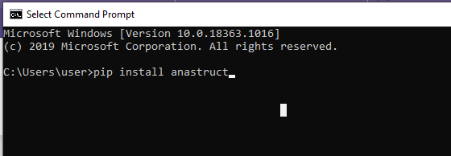

## Step 0 and 3/4: Load the Library and its Class, SystemElements()

```python
from anastruct import SystemElements
mySimulation = SystemElements()
```

## Step 1 (finally): Adding system beam elements

```python
# Adding beam elements follows the simple cartesian system of defining point locations in the (x, y) order...

# making a beam from...
#    x = 0, y = 0
# to............
#    x = 3, y= 4

# Create a list containing 2 lists, each containing the point locations (0,0) and (3, 4)
first_beam_location = [ [0, 0], [3, 4] ]

# Add this element by calling the "add_element() function of our simulation object"
mySimulation.add_element(location=first_beam_location)
```

```
1
```

```python
# We can now add another beam from (3,4) to another point...say (8, 4)?

# We can also go without the intermediate step of defining the first_beam_location,
# and go straight to calling the mySimulation.add_element() function...

mySimulation.add_element(location=[ [3,4], [8, 4]] )
```

```
2
```

## Step 2: Defining fixed point constraints

### So far we have defined 2 beams going from the origin...

```
(0,0) --> (3,4), --> (8, 4)
```

### This now results in 3 total nodes where the beam elements cross.

These are saved internally to the mySimulation object by numerical node id's.  
The first node at origin (0,0) has a node ID of... node_id=1  
The second node at (3,4) has a node ID of... node_id=2  
The third node at (8, 4) has a node ID of... node_id=3

### Now let's say we want to add a FIXED constraint at node (8,4), and a hinged node at the origin node (0,0)...

```python
# Use .add_support_hinged and .add_support_fixed functions to do so, and reference the nodes by their given integer ID's...
mySimulation.add_support_hinged(node_id=1)
mySimulation.add_support_fixed(node_id=3)
```

## Step 3: Defining the applied forces

In the same process of thought that led us to conclude we have 3 nodes, we have 2 total "elements", or beams in the system. The ID's are integers that are saved internally as we add members to the mySimulation object...  
The first element from (0,0) --> (3,4) has an ID of...element_id=1  
The second element from (3,4) --> (8, 4) has an ID of...element_id=2

#### Now let's say we want to add a downwards 'distributed load' AKA a 'q-load'...the following code accomplishes that...

```python
mySimulation.q_load(element_id=2, q=-10)
```

## Step 4: Running the simulation

```python
# simple as calling one function to do all the calculations for you!
# You've already done the hard work of setting up the simulation parameters!! :)))
mySimulation.solve()
```

```
array([ 0.        ,  0.        , -0.00224937,  0.00419425,  0.01197769,
       -0.00182647,  0.        ,  0.        ,  0.        ])
```

## Step 4.9 (last one i promise ;) ): Viewing the structure, reaction forces, axial forces, shear forces and bending moments and displacements...

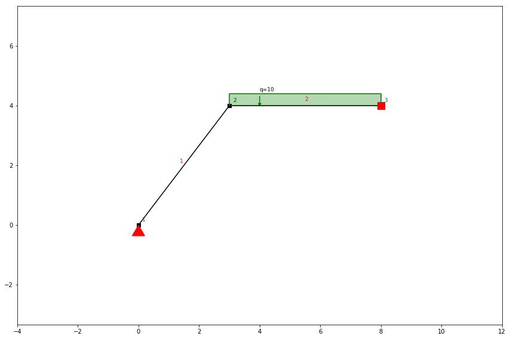

```python
mySimulation.show_structure()
```

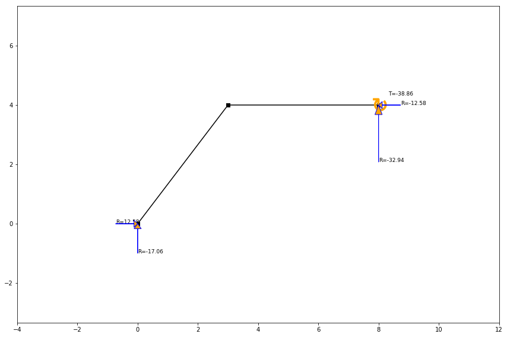

```python
mySimulation.show_reaction_force()
```

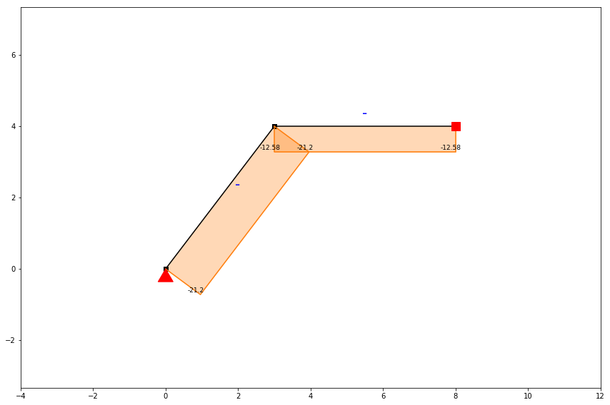

```python
mySimulation.show_axial_force()
```

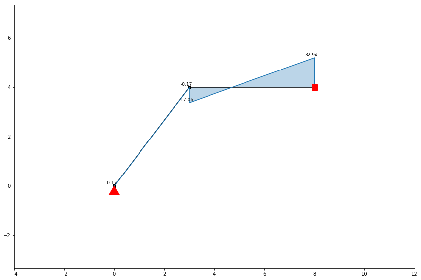

```python
mySimulation.show_shear_force()
```

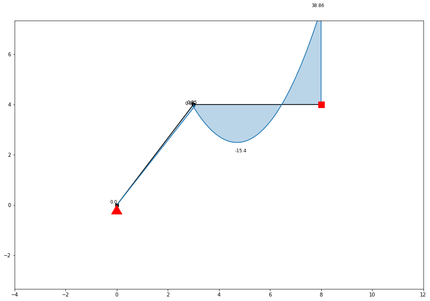

```python
mySimulation.show_bending_moment()
```

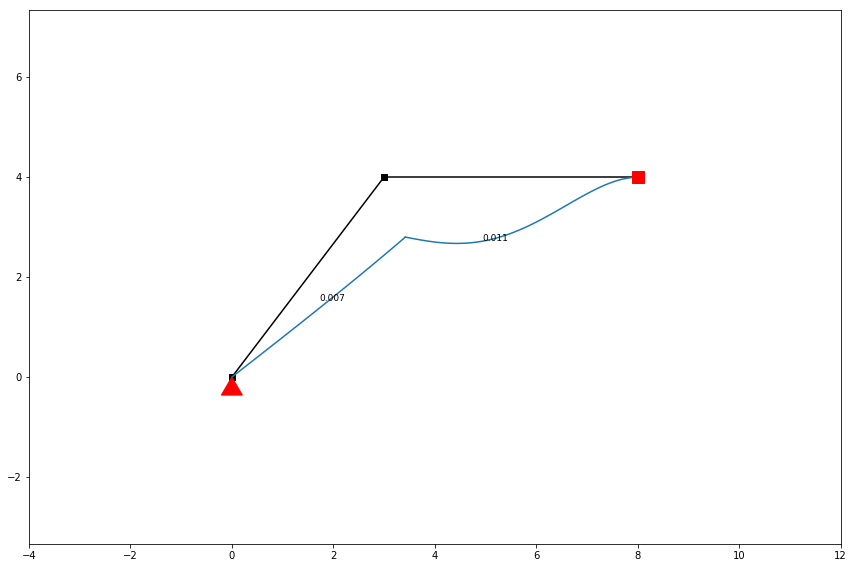

```python
mySimulation.show_displacement()
```

## Congratulations! You can now work for ANSYS! :) ...

## ...not really, but if that's what you want to do, this is a great first step!

Now feel free to message any of the members or executives of the Computational Materials Society for any clarifications in this tutorial. If all else is good, feel free to hop onto the assignment where you'll use this library to construct and simulate a cellular hexagonal structure.

# Building on "Why is this useful?"

In short, I used this library in conjunction with a genetic algorithm library I wrote to do some preliminary research in the MSE department investigating optimization of 3D printed cellular structures reinforcement and placements.

Combining the relatively quick computations of beam element systems vs finite element systems with some easy python scripting, I was able to generate and test some cool structures.

Here is an example structure my algorithm generated after 7 generations of iterative selection, optimizating for stiffness...

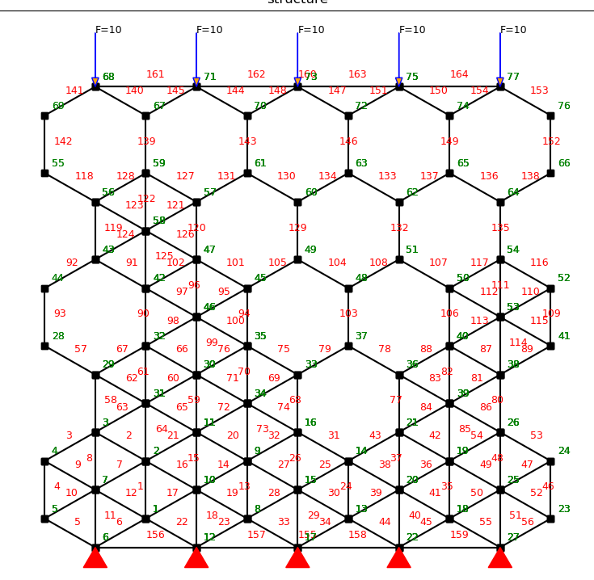

### The assignment following this tutorial will be closely related to this application in scripting to generate hexagonal lattices using anaStruct.